# Navigation Project Report

Here, we will describe the reinforcement learning algorithm and the hyperparameters used to train the agent. We will also discuss possible improvements.

### Base Feed Forward Network

For the base network to estimate Q values, I used a straightforward feed-forward neural network using several blocks of `Linear` layers. I used `BatchNorm1d` to stabilize between the Linear blocks the training by preventing the magnitude of gradients from being too large. `Dropout` was used to try to avoid overfitting since I experimented with deeper and wider networks during hyperparameter search. `LeakyReLU` activation was used instead of the usual `ReLU` because of personal preference.

Uniform Kaiming weight initialization was used with modification for `LeakyReLU` activation.

```python
# Class skeleton adapted from https://github.com/udacity/Value-based-methods/blob/main/dqn/exercise/model.py
class QNetwork(nn.Module):
    """Actor (Policy) Model."""

    def __init__(self, state_size, action_size, hidden_size, depth, dropout, seed):
        """Initialize parameters and build model.
        Params
        ======
            state_size (int): Dimension of each state
            action_size (int): Dimension of each action
            seed (int): Random seed
        """
        super(QNetwork, self).__init__()
        self.seed = torch.manual_seed(seed)
        self.state_size, self.action_size, self.seed = state_size, action_size, np.random.seed(seed)

        def init_weights(m):
            if isinstance(m, nn.Linear):
                torch.nn.init.kaiming_uniform_(m.weight, a=1e-2, mode='fan_in', nonlinearity='leaky_relu')

        layer_sizes = (state_size, ) + (hidden_size, ) * (depth-2) + (action_size,)

        layers = tuple()
        for i in range(len(layer_sizes)-2):
            layers += (nn.Linear(layer_sizes[i], layer_sizes[i+1]),
                       nn.BatchNorm1d(layer_sizes[i+1]),
                       nn.LeakyReLU(1e-2),
                       nn.Dropout(dropout))
        layers += (nn.Linear(layer_sizes[-2], layer_sizes[-1]),)
        self.model = nn.Sequential(*layers)
        self.model.apply(init_weights)

    def forward(self, state):
        """Build a network that maps state -> action values."""
        return self.model(state)
```

### Implementation of Deep Q Network Agent with Replay Buffer

The implementation of DQN with Replay Buffer used here was based on the skeleton architecture used during lesson exercises. DQN architecture with fixed Q targets allow stable training, and the hyperparameter `tau` is used to control the rate of "mixing" the local weights into the target weights.

The default choice of hyperparameters is specified in the `__init__` method.

```python
BUFFER_SIZE = int(1e5)  # replay buffer size
UPDATE_EVERY = 4        # how often to update the network

device = torch.device("cuda:0" if torch.cuda.is_available() else "cpu")
print(f"Using {device}")

# Agent, ReplayBuffer classes adapted from https://github.com/udacity/Value-based-methods/blob/main/dqn/exercise/dqn_agent.py

class Agent():
    """Interacts with and learns from the environment."""

    def __init__(self, state_size, action_size, hidden_size=128,
                 depth=4, dropout=0.4, batch_size=1024,
                 gamma=0.9999, tau=1e-3, lr=3e-4, seed=42):
        """Initialize an Agent object.

        Params
        ======
            state_size (int): dimension of each state
            action_size (int): dimension of each action
            seed (int): random seed
        """
        self.state_size = state_size
        self.action_size = action_size
        self.hidden_size = hidden_size
        self.batch_size = batch_size
        self.gamma = gamma
        self.tau = tau
        self.lr = lr
        self.seed = random.seed(seed)

        # Q-Network
        self.qnetwork_local = QNetwork(state_size, action_size, hidden_size,
                                       depth, dropout, seed).to(device)
        self.qnetwork_target = QNetwork(state_size, action_size, hidden_size,
                                        depth, dropout, seed).to(device)
        self.optimizer = optim.Adam(self.qnetwork_local.parameters(), lr=lr)

        # Replay memory
        self.memory = ReplayBuffer(action_size, BUFFER_SIZE, batch_size, seed)
        # Initialize time step (for updating every UPDATE_EVERY steps)
        self.t_step = 0

    def step(self, state, action, reward, next_state, done):
        # Save experience in replay memory
        self.memory.add(state, action, reward, next_state, done)

        # Learn every UPDATE_EVERY time steps.
        self.t_step = (self.t_step + 1) % UPDATE_EVERY
        if self.t_step == 0:
            # If enough samples are available in memory, get random subset and learn
            if len(self.memory) > self.batch_size:
                experiences = self.memory.sample()
                self.learn(experiences, self.gamma)

    def act(self, state, eps=0.):
        """Returns actions for given state as per current policy.

        Params
        ======
            state (array_like): current state
            eps (float): epsilon, for epsilon-greedy action selection
        """
        state = torch.from_numpy(state).float().unsqueeze(0).to(device)
        self.qnetwork_local.eval()
        with torch.no_grad():
            action_values = self.qnetwork_local(state)
        self.qnetwork_local.train()

        # Epsilon-greedy action selection
        if random.random() > eps:
            return np.argmax(action_values.cpu().data.numpy())
        else:
            return random.choice(np.arange(self.action_size))

    def learn(self, experiences, gamma):
        """Update value parameters using given batch of experience tuples.

        Params
        ======
            experiences (Tuple[torch.Tensor]): tuple of (s, a, r, s', done) tuples
            gamma (float): discount factor
        """
        states, actions, rewards, next_states, dones = experiences

        criterion = F.mse_loss
        with torch.no_grad():
            out = self.qnetwork_target(next_states).detach().max(dim=1, keepdim=True)[0]
        target = rewards + gamma * out * (1-dones)
        value = self.qnetwork_local(states).gather(dim=1, index=actions)
        loss = criterion(value, target.detach())
        self.optimizer.zero_grad()
        loss.backward()
        self.optimizer.step()

        # ------------------- update target network ------------------- #
        self.soft_update(self.qnetwork_local, self.qnetwork_target, self.tau)

    def soft_update(self, local_model, target_model, tau):
        """Soft update model parameters.
        θ_target = τ*θ_local + (1 - τ)*θ_target

        Params
        ======
            local_model (PyTorch model): weights will be copied from
            target_model (PyTorch model): weights will be copied to
            tau (float): interpolation parameter
        """
        for target_param, local_param in zip(target_model.parameters(), local_model.parameters()):
            target_param.data.copy_(tau*local_param.data + (1.0-tau)*target_param.data)


class ReplayBuffer:
    """Fixed-size buffer to store experience tuples."""

    def __init__(self, action_size, buffer_size, batch_size, seed):
        """Initialize a ReplayBuffer object.

        Params
        ======
            action_size (int): dimension of each action
            buffer_size (int): maximum size of buffer
            batch_size (int): size of each training batch
            seed (int): random seed
        """
        self.action_size = action_size
        self.memory = deque(maxlen=buffer_size)
        self.batch_size = batch_size
        self.experience = namedtuple("Experience", field_names=["state", "action", "reward", "next_state", "done"])
        self.seed = random.seed(seed)

    def add(self, state, action, reward, next_state, done):
        """Add a new experience to memory."""
        e = self.experience(state, action, reward, next_state, done)
        self.memory.append(e)

    def sample(self):
        """Randomly sample a batch of experiences from memory."""
        experiences = random.sample(self.memory, k=self.batch_size)

        states = torch.from_numpy(np.vstack([e.state for e in experiences if e is not None])).float().to(device)
        actions = torch.from_numpy(np.vstack([e.action for e in experiences if e is not None])).long().to(device)
        rewards = torch.from_numpy(np.vstack([e.reward for e in experiences if e is not None])).float().to(device)
        next_states = torch.from_numpy(np.vstack([e.next_state for e in experiences if e is not None])).float().to(device)
        dones = torch.from_numpy(np.vstack([e.done for e in experiences if e is not None]).astype(np.uint8)).float().to(device)

        return (states, actions, rewards, next_states, dones)

    def __len__(self):
        """Return the current size of internal memory."""
        return len(self.memory)
```

```
Using cuda:0
```

## Hyperparameter Search

Here, I did not conduct a comprehensive hyperparameter search for the optimal combination of hyperparameters. Instead, I selected a reasonable set of hyperparameters, and experimented with changing only 1 or 2 hyperparameters at a time.

The plots from the hyperparameter search in the `Navigation.ipynb` are shown below for further discussion. Note that the plots are "smoothed" plots using sliding window averages of the trailing 100 scores.

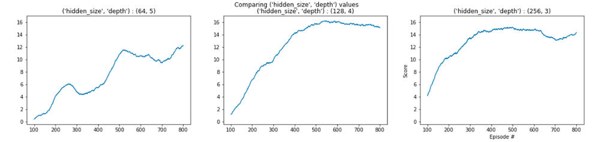

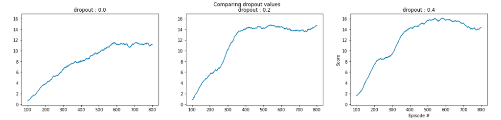

Dropout was used to prevent overfitting of the network. I chose `dropout` probability of 0.4 since it seemed to work well based on the above plot.

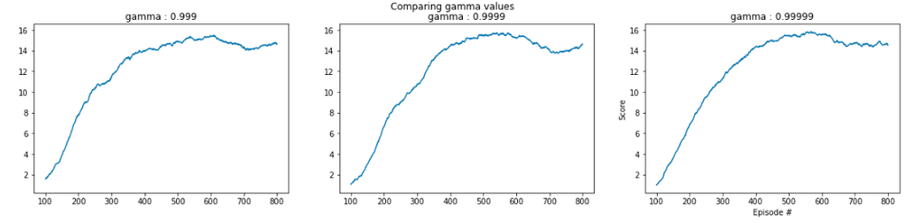

During the first 800 episodes of training, `gamma` values of 0.999, 0.9999, 0.99999 seemed to have very similar performance. I decided on the `gamma` value of 0.9999 rather arbitrarily.

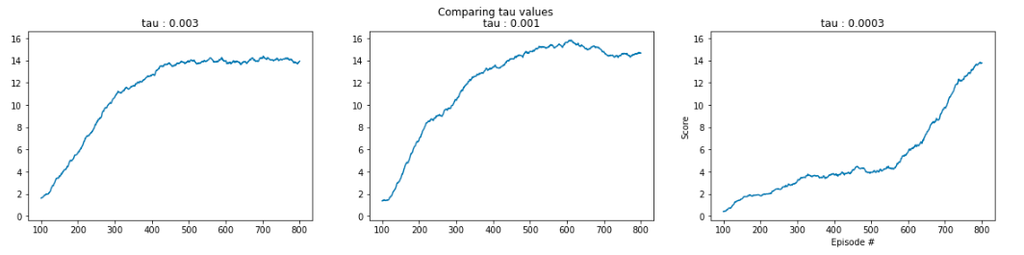

`tau` of 0.001 seemed to perform the best with the rest of the default hyperparameters based on the above plots.

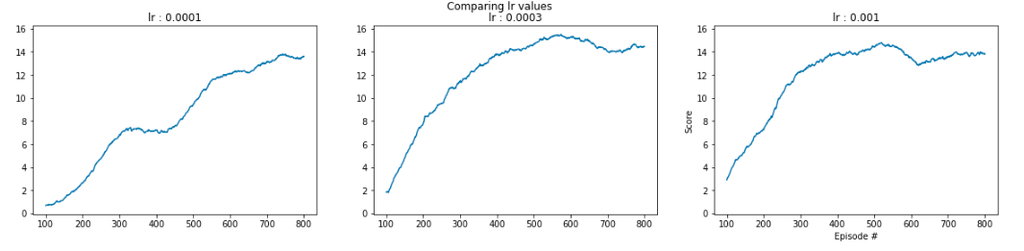

`lr` of `3e-4` appeared to provide a decent combination of initial learning that's not too slow, and good final performance.

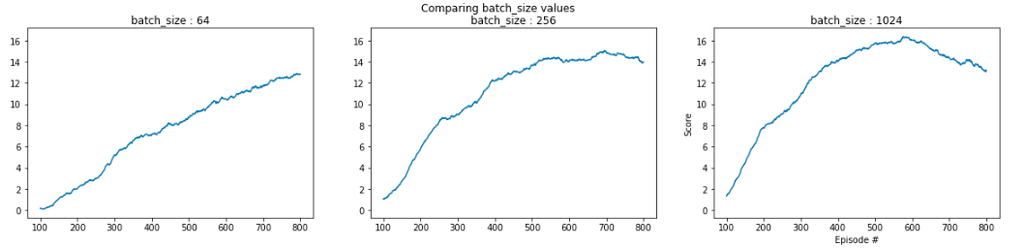

I chose `batch_size` of 1024 because I reasoned the larger the batch size, the more stable the training should be. The large batch size should also make `BatchNorm1d` better.

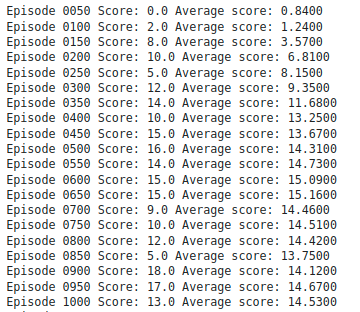

The first 1000 episodes show that after 400 episodes, the average score from the trailing 100 consecutive episodes was > 13.

This is also shown in the below plots of the smoothed plot of the trailing 100 episodes, and the plot of the rewards at each individual episode.

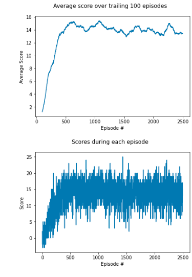

### Considerations for future improvement

Here, I used a vanilla DQN, but use of Double DQN architecture would prevent overestimation of Q-values, resulting in more accurate estimates of Q-values and a better final policy.

In addition, prioritized replay would allow faster convergence of the Q-values by sampling from the Replay Buffer more efficiently.